# HW2

```r
library(nycflights13)
library(tidyverse)
library(maps)
library(data.table)
flights
```

```
# A tibble: 336,776 × 19
    year month   day dep_time sched_dep_time dep_delay arr_time sched_arr_time
   <int> <int> <int>    <int>          <int>     <dbl>    <int>          <int>
 1  2013     1     1      517            515         2      830            819
 2  2013     1     1      533            529         4      850            830
 3  2013     1     1      542            540         2      923            850
 4  2013     1     1      544            545        -1     1004           1022
 5  2013     1     1      554            600        -6      812            837
 6  2013     1     1      554            558        -4      740            728
 7  2013     1     1      555            600        -5      913            854
 8  2013     1     1      557            600        -3      709            723
 9  2013     1     1      557            600        -3      838            846
10  2013     1     1      558            600        -2      753            745
# ℹ 336,766 more rows
# ℹ 11 more variables: arr_delay <dbl>, carrier <chr>, flight <int>,
#   tailnum <chr>, origin <chr>, dest <chr>, air_time <dbl>, distance <dbl>,
#   hour <dbl>, minute <dbl>, time_hour <dttm>
```

Question 1

```r
top_10_destinations <- flights %>%
  count(dest, sort = TRUE) %>%
  head(10)

print(top_10_destinations)
```

```
# A tibble: 10 × 2
   dest      n
   <chr> <int>
 1 ORD   17283
 2 ATL   17215
 3 LAX   16174
 4 BOS   15508
 5 MCO   14082
 6 CLT   14064
 7 SFO   13331
 8 FLL   12055
 9 MIA   11728
10 DCA    9705
```

Answer: The top10 most popular destination and their numbers of flight has been shown in the table.

Question 2

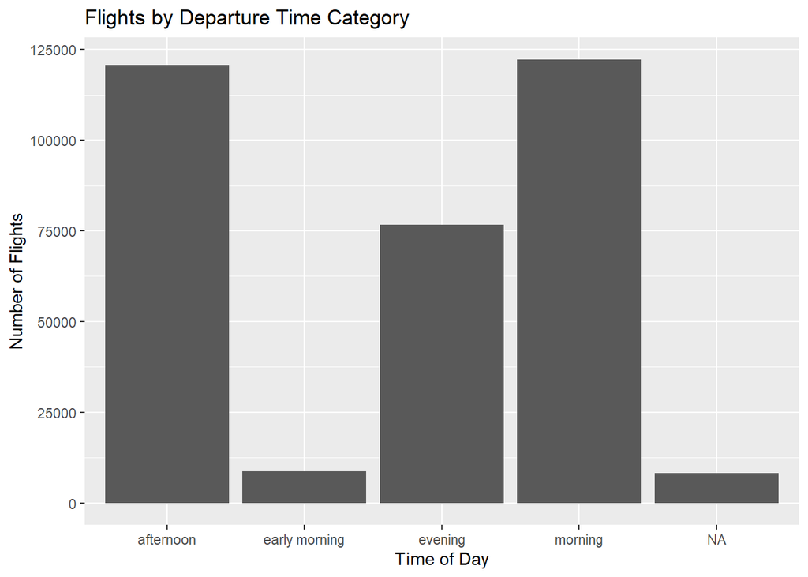

```r
#make the category
flights_with_time_cats <- flights %>%
  mutate(dep_category = case_when(
    dep_time >= 0 & dep_time < 600 ~ "early morning",
    dep_time >= 600 & dep_time < 1200 ~ "morning",
    dep_time >= 1200 & dep_time < 1800 ~ "afternoon",
    dep_time >= 1800 & dep_time <= 2400 ~ "evening"
  ),
  arr_category = case_when(
    arr_time >= 0 & arr_time < 600 ~ "early morning",
    arr_time >= 600 & arr_time < 1200 ~ "morning",
    arr_time >= 1200 & arr_time < 1800 ~ "afternoon",
    arr_time >= 1800 & arr_time <= 2400 ~ "evening"
  ))
#show the barplot
ggplot(flights_with_time_cats, aes(x = dep_category)) +
  geom_bar() +
  labs(title = "Flights by Departure Time Category",
       x = "Time of Day",
       y = "Number of Flights")
```

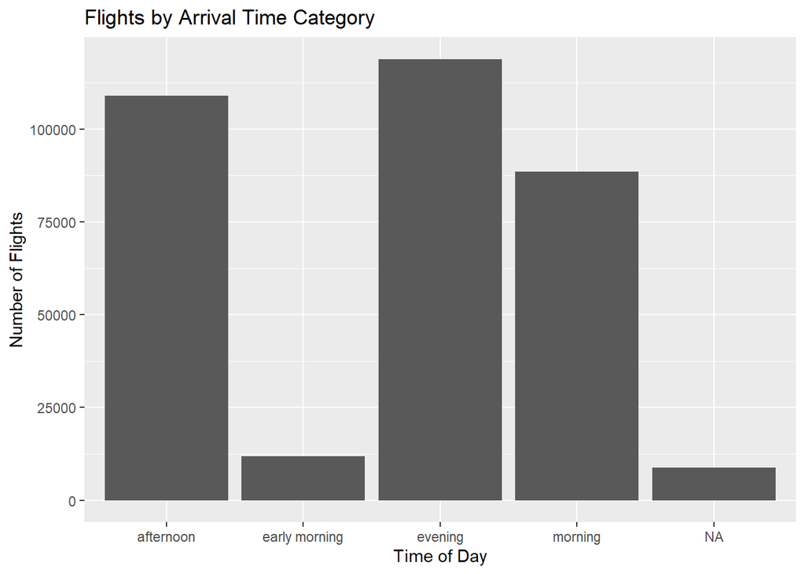

```r
ggplot(flights_with_time_cats, aes(x = arr_category)) +
  geom_bar() +
  labs(title = "Flights by Arrival Time Category",
       x = "Time of Day",
       y = "Number of Flights")
```

```r
#percentage
redeye_flights <- flights_with_time_cats %>%
  filter((dep_category == "afternoon" | dep_category == "evening") &
         (arr_category == "early morning" | arr_category == "morning")) %>%
  nrow()

total_flights <- flights_with_time_cats %>% nrow()

redeye_percentage <- (redeye_flights / total_flights) * 100

print(paste("The percentage of 'red eye' flights is:", redeye_percentage, "%"))
```

```
[1] "The percentage of 'red eye' flights is: 3.15729149345559 %"
```

Question 3

```r
#find out the multiple flight
multiple_airlines_planes <- flights %>%
  select(tailnum, carrier) %>%
  distinct() %>%
  group_by(tailnum) %>%
  count() %>%
  filter(n > 1)

print(multiple_airlines_planes)
```

```
# A tibble: 18 × 2
# Groups:   tailnum [18]
   tailnum     n
   <chr>   <int>
 1 N146PQ      2
 2 N153PQ      2
 3 N176PQ      2
 4 N181PQ      2
 5 N197PQ      2
 6 N200PQ      2
 7 N228PQ      2
 8 N232PQ      2
 9 N933AT      2
10 N935AT      2
11 N977AT      2
12 N978AT      2
13 N979AT      2
14 N981AT      2
15 N989AT      2
16 N990AT      2
17 N994AT      2
18 <NA>        7
```

```r
# To find which airlines they flew for
planes_multiple_airlines_details <- flights %>%
  filter(tailnum %in% multiple_airlines_planes$tailnum) %>%
  select(tailnum, carrier) %>%
  distinct() %>%
  arrange(tailnum, carrier)

print(planes_multiple_airlines_details)
```

```
# A tibble: 41 × 2
   tailnum carrier
   <chr>   <chr>
 1 N146PQ  9E
 2 N146PQ  EV
 3 N153PQ  9E
 4 N153PQ  EV
 5 N176PQ  9E
 6 N176PQ  EV
 7 N181PQ  9E
 8 N181PQ  EV
 9 N197PQ  9E
10 N197PQ  EV
# ℹ 31 more rows
```

There were planes that flew for multiple airlines. 17 planes were there and airlines they fly is shown in the tbl_df table(except the NA value)

Question 4

```r
flights
```

```
# A tibble: 336,776 × 19
    year month   day dep_time sched_dep_time dep_delay arr_time sched_arr_time
   <int> <int> <int>    <int>          <int>     <dbl>    <int>          <int>
 1  2013     1     1      517            515         2      830            819
 2  2013     1     1      533            529         4      850            830
 3  2013     1     1      542            540         2      923            850
 4  2013     1     1      544            545        -1     1004           1022
 5  2013     1     1      554            600        -6      812            837
 6  2013     1     1      554            558        -4      740            728
 7  2013     1     1      555            600        -5      913            854
 8  2013     1     1      557            600        -3      709            723
 9  2013     1     1      557            600        -3      838            846
10  2013     1     1      558            600        -2      753            745
# ℹ 336,766 more rows
# ℹ 11 more variables: arr_delay <dbl>, carrier <chr>, flight <int>,
#   tailnum <chr>, origin <chr>, dest <chr>, air_time <dbl>, distance <dbl>,
#   hour <dbl>, minute <dbl>, time_hour <dttm>
```

```r
weather
```

```
# A tibble: 26,115 × 15
   origin  year month   day  hour  temp  dewp humid wind_dir wind_speed
   <chr>  <int> <int> <int> <int> <dbl> <dbl> <dbl>    <dbl>      <dbl>
 1 EWR     2013     1     1     1  39.0  26.1  59.4      270      10.4
 2 EWR     2013     1     1     2  39.0  27.0  61.6      250       8.06
 3 EWR     2013     1     1     3  39.0  28.0  64.4      240      11.5
 4 EWR     2013     1     1     4  39.9  28.0  62.2      250      12.7
 5 EWR     2013     1     1     5  39.0  28.0  64.4      260      12.7
 6 EWR     2013     1     1     6  37.9  28.0  67.2      240      11.5
 7 EWR     2013     1     1     7  39.0  28.0  64.4      240      15.0
 8 EWR     2013     1     1     8  39.9  28.0  62.2      250      10.4
 9 EWR     2013     1     1     9  39.9  28.0  62.2      260      15.0
10 EWR     2013     1     1    10  41    28.0  59.6      260      13.8
# ℹ 26,105 more rows
# ℹ 5 more variables: wind_gust <dbl>, precip <dbl>, pressure <dbl>,
#   visib <dbl>, time_hour <dttm>
```

```r
airports
```

```
# A tibble: 1,458 × 8
   faa   name                             lat    lon   alt    tz dst   tzone
   <chr> <chr>                          <dbl>  <dbl> <dbl> <dbl> <chr> <chr>
 1 04G   Lansdowne Airport               41.1  -80.6  1044    -5 A     America/…
 2 06A   Moton Field Municipal Airport   32.5  -85.7   264    -6 A     America/…
 3 06C   Schaumburg Regional             42.0  -88.1   801    -6 A     America/…
 4 06N   Randall Airport                 41.4  -74.4   523    -5 A     America/…
 5 09J   Jekyll Island Airport           31.1  -81.4    11    -5 A     America/…
 6 0A9   Elizabethton Municipal Airport  36.4  -82.2  1593    -5 A     America/…
 7 0G6   Williams County Airport         41.5  -84.5   730    -5 A     America/…
 8 0G7   Finger Lakes Regional Airport   42.9  -76.8   492    -5 A     America/…
 9 0P2   Shoestring Aviation Airfield    39.8  -76.6  1000    -5 U     America/…
10 0S9   Jefferson County Intl           48.1 -123.    108    -8 A     America/…
# ℹ 1,448 more rows
```

What is the relationship: The two datasets can be joined by the origin column in the weather table, which corresponds to the faa airport code in the airports table. How it should appear in the diagram: There should be a line connecting the weather and airports data frames, specifically linking the weather.origin variable to the airports.faa variable. This indicates that weather.origin is a foreign key referring to the primary key airports.faa for the three NYC airports.

Question 5

```r
weather_unique <- weather %>%
  unite(col = "weather_id", year, month, day, hour, origin, sep = "_", remove = FALSE)
weather_unique
```

```
# A tibble: 26,115 × 16
   weather_id      origin  year month   day  hour  temp  dewp humid wind_dir
   <chr>           <chr>  <int> <int> <int> <int> <dbl> <dbl> <dbl>    <dbl>
 1 2013_1_1_1_EWR  EWR     2013     1     1     1  39.0  26.1  59.4      270
 2 2013_1_1_2_EWR  EWR     2013     1     1     2  39.0  27.0  61.6      250
 3 2013_1_1_3_EWR  EWR     2013     1     1     3  39.0  28.0  64.4      240
 4 2013_1_1_4_EWR  EWR     2013     1     1     4  39.9  28.0  62.2      250
 5 2013_1_1_5_EWR  EWR     2013     1     1     5  39.0  28.0  64.4      260
 6 2013_1_1_6_EWR  EWR     2013     1     1     6  37.9  28.0  67.2      240
 7 2013_1_1_7_EWR  EWR     2013     1     1     7  39.0  28.0  64.4      240
 8 2013_1_1_8_EWR  EWR     2013     1     1     8  39.9  28.0  62.2      250
 9 2013_1_1_9_EWR  EWR     2013     1     1     9  39.9  28.0  62.2      260
10 2013_1_1_10_EWR EWR     2013     1     1    10  41    28.0  59.6      260
# ℹ 26,105 more rows
# ℹ 6 more variables: wind_speed <dbl>, wind_gust <dbl>, precip <dbl>,
#   pressure <dbl>, visib <dbl>, time_hour <dttm>
```

```r
# Check for duplicates
num_duplicates <- sum(duplicated(weather_unique$weather_id))
print(paste("Number of duplicated values:", num_duplicates))
```

```
[1] "Number of duplicated values: 3"
```

There should be 0 duplicated value because after combined those 5 variables in one unit, each value is unique and there is no other value that can be the same to it. But the results is 3,the documentation for nycflights13 mentions a specific data entry error on November 3, 2013, at 1 AM, where some records were duplicated. This is why using year, month, day, hour, and origin does not result in a perfectly unique key。

merge the data

```r
merged_flights_weather <- flights %>%
  inner_join(weather, by = c("origin", "time_hour"))
merged_flights_weather
```

```
# A tibble: 335,220 × 32
   year.x month.x day.x dep_time sched_dep_time dep_delay arr_time
    <int>   <int> <int>    <int>          <int>     <dbl>    <int>
 1   2013       1     1      517            515         2      830
 2   2013       1     1      533            529         4      850
 3   2013       1     1      542            540         2      923
 4   2013       1     1      544            545        -1     1004
 5   2013       1     1      554            600        -6      812
 6   2013       1     1      554            558        -4      740
 7   2013       1     1      555            600        -5      913
 8   2013       1     1      557            600        -3      709
 9   2013       1     1      557            600        -3      838
10   2013       1     1      558            600        -2      753
# ℹ 335,210 more rows
# ℹ 25 more variables: sched_arr_time <int>, arr_delay <dbl>, carrier <chr>,
#   flight <int>, tailnum <chr>, origin <chr>, dest <chr>, air_time <dbl>,
#   distance <dbl>, hour.x <dbl>, minute <dbl>, time_hour <dttm>, year.y <int>,
#   month.y <int>, day.y <int>, hour.y <int>, temp <dbl>, dewp <dbl>,
#   humid <dbl>, wind_dir <dbl>, wind_speed <dbl>, wind_gust <dbl>,
#   precip <dbl>, pressure <dbl>, visib <dbl>
```

Question 6

```r
#STEP2:
dim(merged_flights_weather)
```

```
[1] 335220     32
```

```r
cat("The merged dataset has", nrow(merged_flights_weather), "rows and", ncol(merged_flights_weather), "columns.\n")
```

```
The merged dataset has 335220 rows and 32 columns.
```

```r
#STEP3:
glimpse(merged_flights_weather)
```

```
Rows: 335,220
Columns: 32
$ year.x         <int> 2013, 2013, 2013, 2013, 2013, 2013, 2013, 2013, 2013, 2…
$ month.x        <int> 1, 1, 1, 1, 1, 1, 1, 1, 1, 1, 1, 1, 1, 1, 1, 1, 1, 1, 1…
$ day.x          <int> 1, 1, 1, 1, 1, 1, 1, 1, 1, 1, 1, 1, 1, 1, 1, 1, 1, 1, 1…
$ dep_time       <int> 517, 533, 542, 544, 554, 554, 555, 557, 557, 558, 558, …
$ sched_dep_time <int> 515, 529, 540, 545, 600, 558, 600, 600, 600, 600, 600, …
$ dep_delay      <dbl> 2, 4, 2, -1, -6, -4, -5, -3, -3, -2, -2, -2, -2, -2, -1…
$ arr_time       <int> 830, 850, 923, 1004, 812, 740, 913, 709, 838, 753, 849,…
$ sched_arr_time <int> 819, 830, 850, 1022, 837, 728, 854, 723, 846, 745, 851,…
$ arr_delay      <dbl> 11, 20, 33, -18, -25, 12, 19, -14, -8, 8, -2, -3, 7, -1…
$ carrier        <chr> "UA", "UA", "AA", "B6", "DL", "UA", "B6", "EV", "B6", "…
$ flight         <int> 1545, 1714, 1141, 725, 461, 1696, 507, 5708, 79, 301, 4…
$ tailnum        <chr> "N14228", "N24211", "N619AA", "N804JB", "N668DN", "N394…
$ origin         <chr> "EWR", "LGA", "JFK", "JFK", "LGA", "EWR", "EWR", "LGA",…
```

[output cut: 19 more lines]

```r
#STEP4:
head(merged_flights_weather)
```

```
# A tibble: 6 × 32
  year.x month.x day.x dep_time sched_dep_time dep_delay arr_time sched_arr_time
   <int>   <int> <int>    <int>          <int>     <dbl>    <int>          <int>
1   2013       1     1      517            515         2      830            819
2   2013       1     1      533            529         4      850            830
3   2013       1     1      542            540         2      923            850
4   2013       1     1      544            545        -1     1004           1022
5   2013       1     1      554            600        -6      812            837
6   2013       1     1      554            558        -4      740            728
# ℹ 24 more variables: arr_delay <dbl>, carrier <chr>, flight <int>,
#   tailnum <chr>, origin <chr>, dest <chr>, air_time <dbl>, distance <dbl>,
#   hour.x <dbl>, minute <dbl>, time_hour <dttm>, year.y <int>, month.y <int>,
#   day.y <int>, hour.y <int>, temp <dbl>, dewp <dbl>, humid <dbl>,
#   wind_dir <dbl>, wind_speed <dbl>, wind_gust <dbl>, precip <dbl>,
#   pressure <dbl>, visib <dbl>
```

```r
tail(merged_flights_weather)
```

```
# A tibble: 6 × 32
  year.x month.x day.x dep_time sched_dep_time dep_delay arr_time sched_arr_time
   <int>   <int> <int>    <int>          <int>     <dbl>    <int>          <int>
1   2013       9    30       NA           1842        NA       NA           2019
2   2013       9    30       NA           1455        NA       NA           1634
3   2013       9    30       NA           2200        NA       NA           2312
4   2013       9    30       NA           1210        NA       NA           1330
5   2013       9    30       NA           1159        NA       NA           1344
6   2013       9    30       NA            840        NA       NA           1020
# ℹ 24 more variables: arr_delay <dbl>, carrier <chr>, flight <int>,
#   tailnum <chr>, origin <chr>, dest <chr>, air_time <dbl>, distance <dbl>,
#   hour.x <dbl>, minute <dbl>, time_hour <dttm>, year.y <int>, month.y <int>,
#   day.y <int>, hour.y <int>, temp <dbl>, dewp <dbl>, humid <dbl>,
#   wind_dir <dbl>, wind_speed <dbl>, wind_gust <dbl>, precip <dbl>,
#   pressure <dbl>, visib <dbl>
```

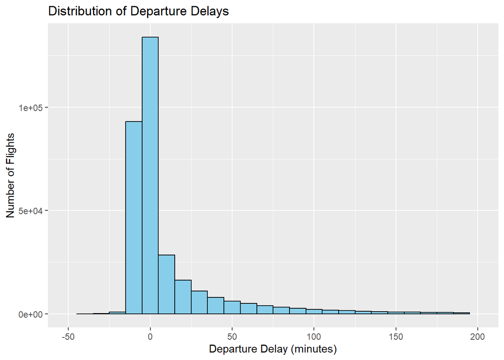

```r
#STEP5:
#de-delay
ggplot(merged_flights_weather, aes(x = dep_delay)) +
  geom_histogram(binwidth = 10, fill = "skyblue", color = "black") +
  xlim(-50, 200) +
  labs(title = "Distribution of Departure Delays", x = "Departure Delay (minutes)", y = "Number of Flights")
```

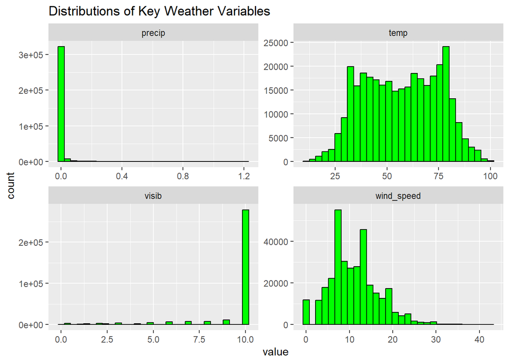

```r
#key weather variables
merged_flights_weather %>%
  select(temp, wind_speed, precip, visib) %>%
  tidyr::pivot_longer(everything()) %>%
  ggplot(aes(x = value)) +
  geom_histogram(bins = 30, fill = "green", color = "black") +
  facet_wrap(~name, scales = "free") +
  labs(title = "Distributions of Key Weather Variables")
```

Question 7

```r
#day
flights_dt <- as.data.table(flights)
daily_avg_delay_dt <- flights_dt[, .(avg_dep_delay = mean(dep_delay, na.rm = TRUE)), by = .(year, month, day)]
worst_day_dt <- daily_avg_delay_dt[order(-avg_dep_delay)][1]
print(worst_day_dt)
```

```
    year month   day avg_dep_delay
   <int> <int> <int>         <num>
1:  2013     3     8      83.53692
```

```r
#day and origin
daily_origin_avg_delay_dt <- flights_dt[, .(avg_dep_delay = mean(dep_delay, na.rm = TRUE)), by = .(year, month, day, origin)]
worst_day_origin_dt <- daily_origin_avg_delay_dt[order(-avg_dep_delay)][1]
print(worst_day_origin_dt)
```

```
    year month   day origin avg_dep_delay
   <int> <int> <int> <char>         <num>
1:  2013     3     8    LGA      105.7249
```

```r
#hour and origin
hourly_origin_avg_delay_dt <- flights_dt[, hour := floor(dep_time / 100)]
hourly_origin_avg_delay_dt <- hourly_origin_avg_delay_dt[, .(avg_dep_delay = mean(dep_delay, na.rm = TRUE)), by = .(year, month, day, hour, origin)]
worst_hour_origin_dt <- hourly_origin_avg_delay_dt[order(-avg_dep_delay)][1]
print(worst_hour_origin_dt)
```

```
    year month   day  hour origin avg_dep_delay
   <int> <int> <int> <num> <char>         <num>
1:  2013     3    17    23    LGA           911
```

It could be seen from the calculation that 2013/3/8 had the worst average length of delay for departures LGA airport had the worst single day for delays at 3/8 LGA airport had the worst single hour for delays on 3/17

Question 8

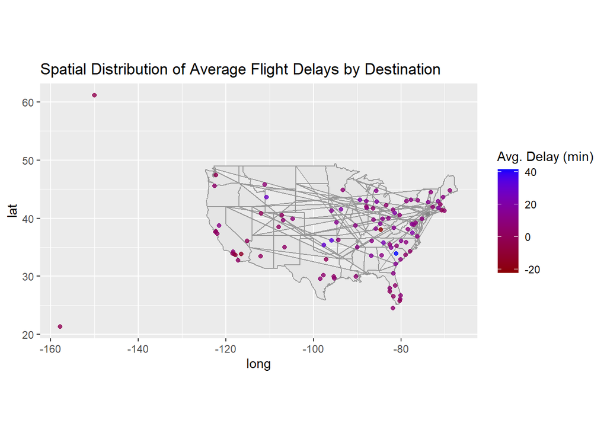

```r
avg_delay_by_dest <- flights %>%
  group_by(dest) %>%
  summarise(avg_arr_delay = mean(arr_delay, na.rm = TRUE))

airports_with_delay <- airports %>%
  inner_join(avg_delay_by_dest, by = c("faa" = "dest"))
us_map <- map_data("state")

ggplot(us_map, aes(x = long, y = lat)) +
  geom_polygon(fill = "gray90", color = "gray60") +
  geom_point(data = airports_with_delay, aes(x = lon, y = lat, color = avg_arr_delay), alpha = 0.8) +
  scale_color_gradient(low = "darkred", high = "blue", name = "Avg. Delay (min)") +
  coord_quickmap() +
  labs(title = "Spatial Distribution of Average Flight Delays by Destination")
```

Question 9 1.define “bad weather” and calculate the average delay in those conditions compared to “good weather”

```r
bad_weather_flights <- merged_flights_weather %>%
  filter(precip > 0.05 | visib < 2 | wind_speed > 25)

good_weather_flights <- merged_flights_weather %>%
  filter(precip == 0 & visib >= 10 & wind_speed <= 10)

avg_delay_bad_weather <- mean(bad_weather_flights$dep_delay, na.rm = TRUE)

avg_delay_good_weather <- mean(good_weather_flights$dep_delay, na.rm = TRUE)

cat("Average departure delay during bad weather:", round(avg_delay_bad_weather, 2), "minutes\n")
```

```
Average departure delay during bad weather: 28.6 minutes
```

```r
cat("Average departure delay during good weather:", round(avg_delay_good_weather, 2), "minutes\n")
```

```
Average departure delay during good weather: 8.91 minutes
```

Comparison of average delays in “bad” vs. “good” weather is a strong indicator. The results show that avg_delay_bad_weather is significantly higher than avg_delay_good_weather, it suggests that bad weather(as defined) can have large impact on delays

2.The correlation matrix plot visually confirms which weather variables are most correlated with delays. A stronger positive correlation between a weather variable and dep_delay indicates a stronger impact.

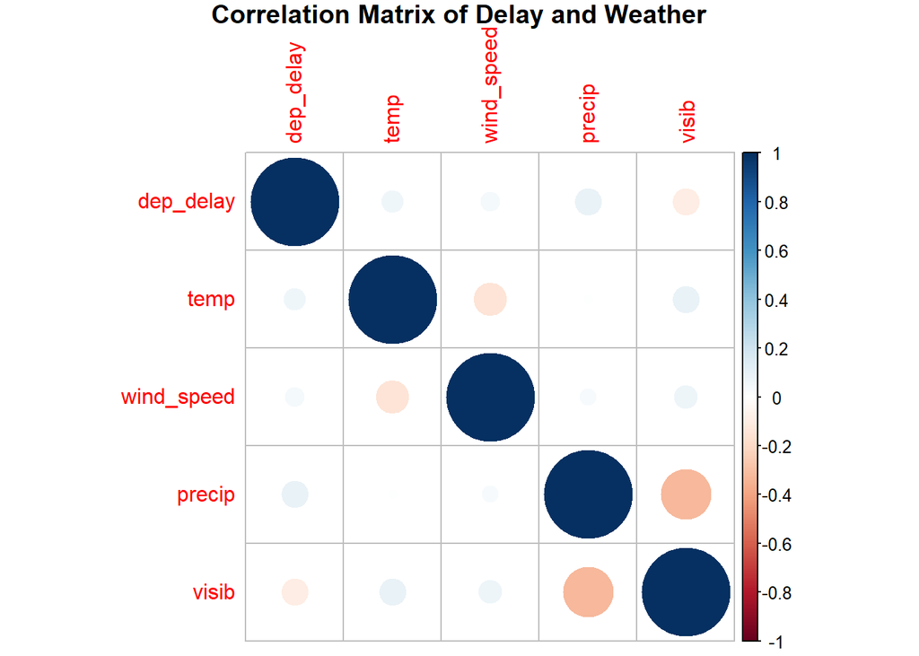

```r
library(corrplot)
cor_matrix <- merged_flights_weather %>%
  select(dep_delay, temp, wind_speed, precip, visib) %>%
  cor(use = "complete.obs")

corrplot(cor_matrix, method = "circle", title = "Correlation Matrix of Delay and Weather", mar = c(0, 0, 1, 0))
```

The correlation matrix will provide a more precise measure of which weather variables have the strongest linear relationship with departure delays. Variables visib (visibility) show strongest negative correlation with dep_delay (lower visibility means higher delay), while variables precip(precipitation ) show strongest positive correlation.

3.This boxplot visualizes how the distribution of departure delays changes with different levels of precipitation(strongest correlation as previous plot said). It’s a good way to see if heavier rain is associated with a wider spread of delays or higher median delays.

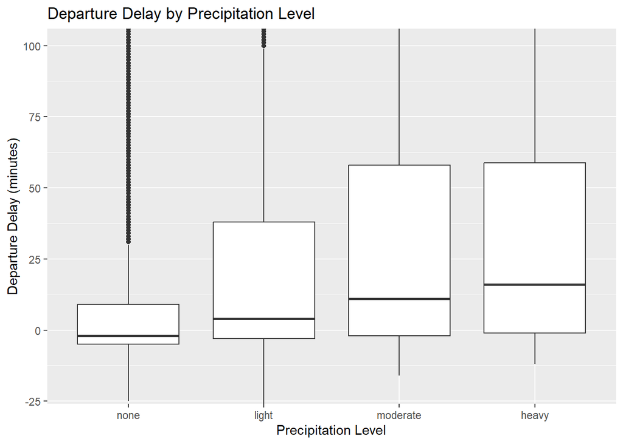

```r
# Categorize precipitation for plotting
merged_flights_weather %>%
  mutate(precip_cat = cut(precip,
                          breaks = c(-0.1, 0.001, 0.1, 0.5, 100),
                          labels = c("none", "light", "moderate", "heavy"))) %>%
  ggplot(aes(x = precip_cat, y = dep_delay)) +
  geom_boxplot(na.rm = TRUE) +
  coord_cartesian(ylim = c(-20, 100)) + # Limit y-axis for better visualization
  labs(title = "Departure Delay by Precipitation Level",
       x = "Precipitation Level",
       y = "Departure Delay (minutes)")
```

It can be seen that the median have positive correlation to rain levels.And after level of moderate rain levels(50%),the range of delay remains almost the same, which means that the impact of precipitation level to delay gets weaken after certain extent.

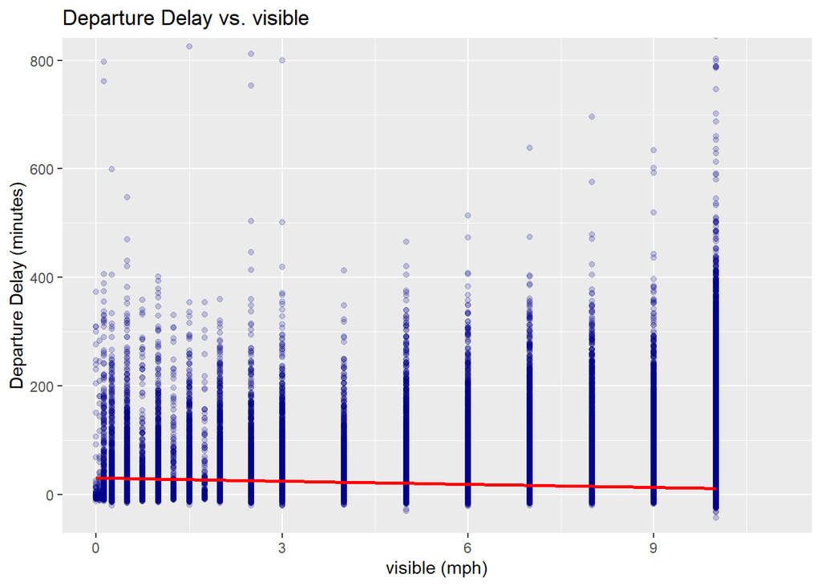

```r
ggplot(merged_flights_weather, aes(x = visib, y = dep_delay)) +
  geom_point(alpha = 0.2, color = "darkblue") +
  geom_smooth(method = "lm", color = "red", se = FALSE) +
  coord_cartesian(ylim = c(-30, 800), xlim = c(0, 11)) +
  labs(title = "Departure Delay vs. visible",
       x = "visible (mph)",
       y = "Departure Delay (minutes)")
```

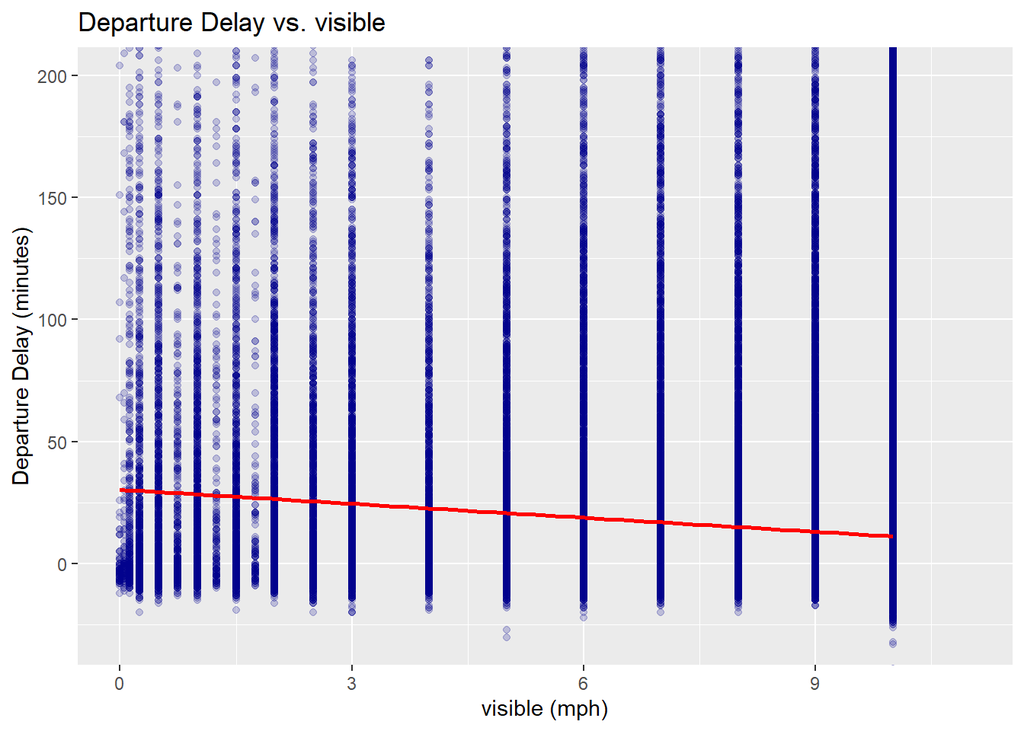

```r
ggplot(merged_flights_weather, aes(x = visib, y = dep_delay)) +
  geom_point(alpha = 0.2, color = "darkblue") +
  geom_smooth(method = "lm", color = "red", se = FALSE) +
  coord_cartesian(ylim = c(-30, 200), xlim = c(0, 11)) +
  labs(title = "Departure Delay vs. visible",
       x = "visible (mph)",
       y = "Departure Delay (minutes)")
```

It could be seen from the linear regression that the visibility show negative correlation with dep_delay, but interesting thing is the whole plot(like the plot 1) will not tell you this thing, this could probably because only limited number of flights have extreme delays compared to the whole number, so the range and the frequency showni in color can’t tell so many informations.